# poisson_regression_multiple_inputs

### Poisson regression example

More realistic example with multiple continuous inputs.

## Import Modules

```python
import numpy as np
import pandas as pd
import matplotlib.pyplot as plt

import seaborn as sns
```

The models will be fit using statsmodels.

```python
import statsmodels.formula.api as smf
import statsmodels.api as sm
```

## Read data

```python
dfB = pd.read_csv('week_09_poisson_B.csv')
```

```python
dfB.info()
```

```
<class 'pandas.core.frame.DataFrame'>
RangeIndex: 51 entries, 0 to 50
Data columns (total 4 columns):
 #   Column  Non-Null Count  Dtype
---  ------  --------------  -----
 0   x1      51 non-null     float64
 1   x2      51 non-null     float64
 2   x3      51 non-null     float64
 3   y       51 non-null     int64
dtypes: float64(3), int64(1)
memory usage: 1.7 KB
```

```python
dfB.isna().sum()
```

```
x1    0
x2    0
x3    0
y     0
dtype: int64
```

```python
dfB.nunique()
```

```
x1    51
x2    51
x3    51
y     10
dtype: int64
```

```python
dfB.head()
```

|  | x1 | x2 | x3 | y |
| --- | --- | --- | --- | --- |
| 0 | -0.785973 | -1.327280 | -0.373309 | 2 |
| 1 | 0.054739 | 0.932546 | -1.527747 | 0 |
| 2 | -1.172560 | 0.276098 | 0.779124 | 0 |
| 3 | -0.167313 | 0.853427 | 1.430752 | 0 |
| 4 | -1.865032 | -0.466554 | 0.004602 | 0 |

We need to know the **context** of the output variable to truly know we are working with COUNTS or **NUMBER OF EVENTS DURING AN INTERVAL OF TIME**.

## EDA

Marginal distributions of INPUTS!

Relationships between inputs!!!

Marginal distributions of the OUTPUTS!

Relationships of the OUTPUT to INPUTS!

Input distributions with histograms or kde density plots.

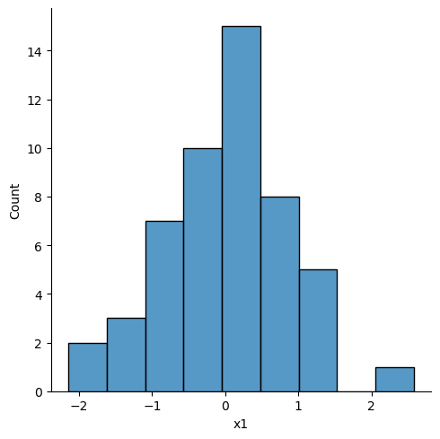

```python
sns.displot( data = dfB, x='x1', kind='hist')

plt.show()
```

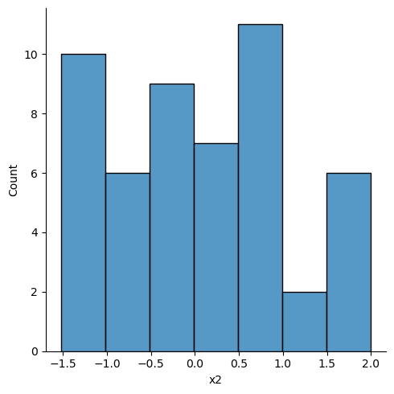

```python
sns.displot(data = dfB, x='x2', kind='hist')

plt.show()
```

We can use LONG-FORMAT data to streamline the exploration by enabling **FACETS** or subplots for each input.

```python
dfB.head()
```

|  | x1 | x2 | x3 | y |
| --- | --- | --- | --- | --- |
| 0 | -0.785973 | -1.327280 | -0.373309 | 2 |
| 1 | 0.054739 | 0.932546 | -1.527747 | 0 |
| 2 | -1.172560 | 0.276098 | 0.779124 | 0 |
| 3 | -0.167313 | 0.853427 | 1.430752 | 0 |
| 4 | -1.865032 | -0.466554 | 0.004602 | 0 |

Let's RESHAPE to LONG-FORMAT we can "STACK" all inputs on top of each other. Do **NOT** stacking the output with the inputs!!!

If we had categorical inputs, those categorical variables would also **NOT** be stacked with the **continuous** inputs!!!

```python
dfB.reset_index().rename(columns={'index': 'rowid'}).\
melt(id_vars=['rowid','y'], ignore_index=True)
```

|  | rowid | y | variable | value |
| --- | --- | --- | --- | --- |
| 0 | 0 | 2 | x1 | -0.785973 |
| 1 | 1 | 0 | x1 | 0.054739 |
| 2 | 2 | 0 | x1 | -1.172560 |
| 3 | 3 | 0 | x1 | -0.167313 |
| 4 | 4 | 0 | x1 | -1.865032 |
| ... | ... | ... | ... | ... |
| 148 | 46 | 2 | x3 | 1.344949 |
| 149 | 47 | 6 | x3 | 0.788015 |
| 150 | 48 | 1 | x3 | -1.107037 |
| 151 | 49 | 3 | x3 | 1.318008 |
| 152 | 50 | 0 | x3 | -0.894084 |

153 rows × 4 columns

Check the tail of the original dataset to confirm the reshaping worked as expected.

```python
dfB.tail()
```

|  | x1 | x2 | x3 | y |
| --- | --- | --- | --- | --- |
| 46 | 1.073753 | 1.718815 | 1.344949 | 2 |
| 47 | 0.081935 | -1.517783 | 0.788015 | 6 |
| 48 | -0.999397 | -0.774869 | -1.107037 | 1 |
| 49 | 0.483927 | 0.909618 | 1.318008 | 3 |
| 50 | -0.153693 | 0.885917 | -0.894084 | 0 |

Assign the long-format to a new object.

```python
lfB = dfB.reset_index().rename(columns={'index': 'rowid'}).\
melt(id_vars=['rowid','y'], ignore_index=True)
```

```python
lfB
```

|  | rowid | y | variable | value |
| --- | --- | --- | --- | --- |
| 0 | 0 | 2 | x1 | -0.785973 |
| 1 | 1 | 0 | x1 | 0.054739 |
| 2 | 2 | 0 | x1 | -1.172560 |
| 3 | 3 | 0 | x1 | -0.167313 |
| 4 | 4 | 0 | x1 | -1.865032 |
| ... | ... | ... | ... | ... |
| 148 | 46 | 2 | x3 | 1.344949 |
| 149 | 47 | 6 | x3 | 0.788015 |
| 150 | 48 | 1 | x3 | -1.107037 |
| 151 | 49 | 3 | x3 | 1.318008 |
| 152 | 50 | 0 | x3 | -0.894084 |

153 rows × 4 columns

The facets can be associated with the `variable` column in the long format data!

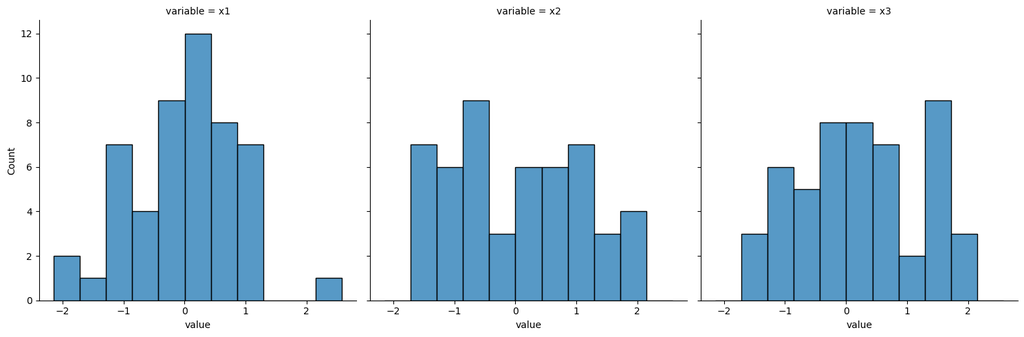

```python
sns.displot(data = lfB, x='value', col='variable', kind='hist', bins = 11)

plt.show()
```

If we had used the wide-format plotting options...then we could have seen a boxplot for each input within a single figure.

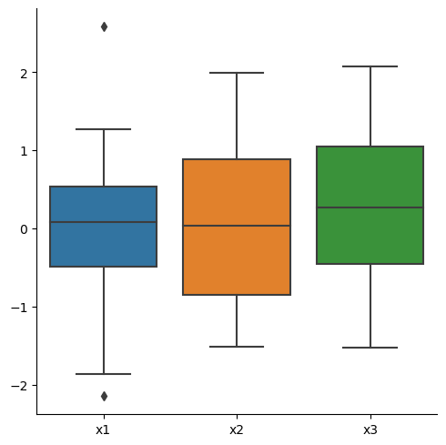

```python
sns.catplot(data = dfB.loc[:, ['x1', 'x2', 'x3']], kind='box')

plt.show()
```

Next, we need to consider the INPUT to INPUT relationships! We need to be worried about if the INPUTS are CORRELATED!!!!!!!!

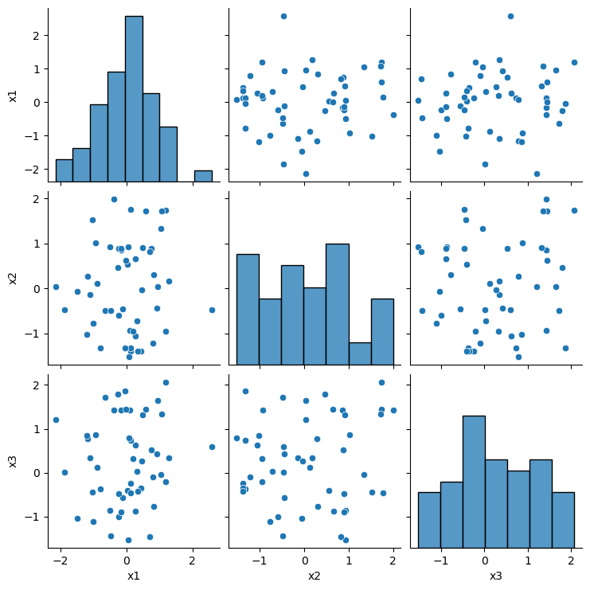

```python
sns.pairplot( data = dfB.loc[:, ['x1', 'x2', 'x3']] )

plt.show()
```

Or we can summarize the relationships with correlation plots!!!!!

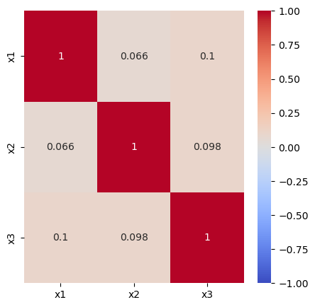

```python
fig, ax = plt.subplots(figsize=(5,5))

sns.heatmap( dfB.loc[:, ['x1', 'x2', 'x3']].corr(),
             vmin=-1, vmax=1, center = 0, cmap='coolwarm',
            annot=True)

plt.show()
```

Since we are working with **count** output...the marginal histogram of the output variable could be created with a `binwidth` of 1. It is critical to first check the number of unique values before creating a histogram with `binwidth=1`. If the counts are very large and there are thousands of unique values the histogram may take a very long time to create.

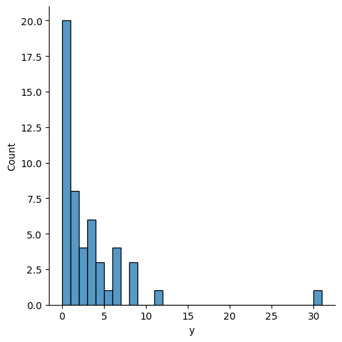

```python
sns.displot( data = dfB, x='y', kind='hist', binwidth = 1)

plt.show()
```

Usually when the number of unique values is small, I will recommend treating the variable as categorical even if the values are numbers.

EXCEPT!!!!!!!!

I do **NOT** recommend doing this for **COUNT** data!!!!!

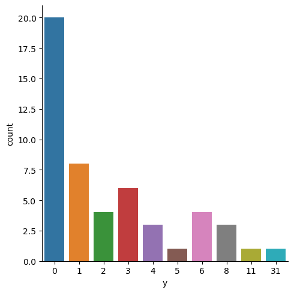

```python
sns.catplot(data = dfB, x='y', kind='count')

plt.show()
```

We can use the `.describe()` method to confirm the LOWER bound or MINIMUM on each variable.

```python
dfB.describe()
```

|  | x1 | x2 | x3 | y |
| --- | --- | --- | --- | --- |
| count | 51.000000 | 51.000000 | 51.000000 | 51.000000 |
| mean | 0.009796 | 0.043823 | 0.248189 | 2.764706 |
| std | 0.880356 | 1.014562 | 0.979419 | 4.856288 |
| min | -2.145065 | -1.517783 | -1.527747 | 0.000000 |
| 25% | -0.489941 | -0.853472 | -0.450766 | 0.000000 |
| 50% | 0.081935 | 0.037403 | 0.262895 | 1.000000 |
| 75% | 0.538634 | 0.883781 | 1.041239 | 3.500000 |
| max | 2.579731 | 1.994359 | 2.070264 | 31.000000 |

Lastly, let's look at the OUTPUT to INPUT relationships via scatter plots. We will use the LONG-FORMAT data so all inputs are contained within facets.

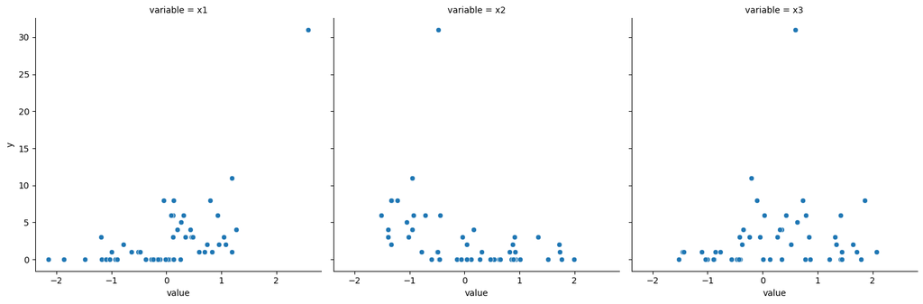

```python
sns.relplot( data = lfB, x='value', y='y', col='variable' )

plt.show()
```

### Likelihood and output data type

When we have COUNT output, the **level of variation** changes as the AVERAGE number of events changes!!!!

We cannot use "regular" regression with linear models because we need the **VARIANCE of the OUTPUT** to change as the input changes!!!!! Regular linear models assume the output variance is CONSTANT!!!!!!

The output data type dictates the LIKELIHOOD which dictates the kind of model we can use!!!

Continuous outputs - regression with Gaussian likelihood.

Binary outputs - classification with logistic regression via Bernoulli likelihood.

Count outputs - Poisson regression via Poisson likelihoods.

If we MISTAKENLY fit a linear model to predict the AVERAGE COUNT...we can have NEGATIVE NUMBERS!!! Do **NOT** do the following when working with COUNT DATA!!!!

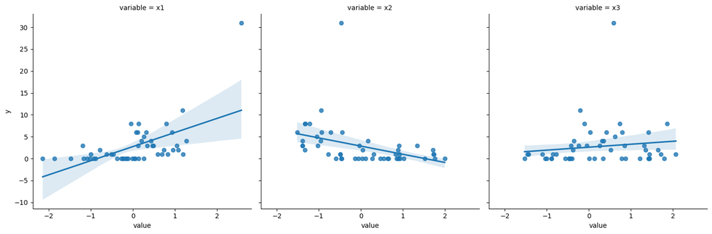

```python
sns.lmplot( data = lfB, x='value', y='y', col='variable' )

plt.show()
```

## Fit models

We do **NOT** need to preprocess the INPUTS for this application because all inputs are centered around 0 already with roughly the same scale.

We will fit the models using Poisson regression via `statsmodels`. The interface is VERY similar to "regular" linear models via `smf.ols()` and logistic regression via `smf.logit()`.

The basic function call is `smf.poisson()`.

Let's start very simple with an INTERCEPT-ONLY or UNKNOWN constant average model!!!!

Poisson regression does **NOT** have an analytic or closed form expression for the regression coefficients, just like Logistic regression. There is NO OLS formula for Poisson regression!!! An optimization algorithm is used behind the scenes to estimate the coefficients.

```python
mod_00 = smf.poisson( 'y ~ 1', data = dfB ).fit()
```

```
Optimization terminated successfully.
         Current function value: 3.513381
         Iterations 1
```

The intercept estimate is below.

```python
mod_00.params
```

```
Intercept    1.016934
dtype: float64
```

The intercept does **NOT** equal the average output!

```python
dfB.y.mean()
```

```
2.764705882352941
```

Behind the scenes, Poisson regression **does NOT** model the average output or average count directly!!!

Instead, we model the **log average output**!!! The intercept is therefore the **log average counts**!!!!

This is analogous to how logistic regression does **NOT** model the probability of the event. Instead, logistic regression models the **log-odds ratio**!!!!!!

The average output is therefore **TRANSFORMED** and we provide a *LINEAR MODEL* on the TRANSFORMED OUTPUT!!! The transformation function is known as the **LINK FUNCTION**.

We must apply the **INVERSE LINK** to calculate the average output from the estimated INTERCEPT!!! The inverse link for Poisson regression is the exponential.

```python
np.exp( mod_00.params )
```

```
Intercept    2.764706
dtype: float64
```

Basically...we cannot use `smf.ols()` even though the OUTPUT is a number!!!

Let's now fit some more meaningful models...just to demonstrate let's begin by using each input separately.

```python
mod_01 = smf.poisson( 'y ~ x1', data = dfB).fit()
```

```
Optimization terminated successfully.
         Current function value: 2.155294
         Iterations 6
```

```python
mod_02 = smf.poisson( 'y ~ x2', data = dfB).fit()
```

```
Optimization terminated successfully.
         Current function value: 2.813625
         Iterations 6
```

```python
mod_03 = smf.poisson( 'y ~ x3', data = dfB).fit()
```

```
Optimization terminated successfully.
         Current function value: 3.435838
         Iterations 5
```

Let's examine statistical significance by visualizing the coefficient summaries.

```python
def my_coefplot(model_object, figsize_use=(10,5)):
    fig, ax = plt.subplots(figsize=figsize_use)

    ax.errorbar(y = model_object.params.index,
                x = model_object.params,
                fmt = 'o', color = 'black', ecolor='black',
                xerr = 2 * model_object.bse,
                elinewidth = 3, ms = 10)

    ax.axvline(x=0, linestyle='--', linewidth=5, color='grey')

    ax.set_xlabel('coefficient value')
    ax.set_ylabel('coefficient name')

    plt.show()
```

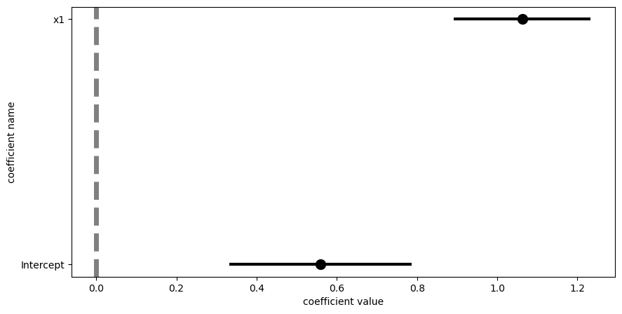

```python
my_coefplot( mod_01 )
```

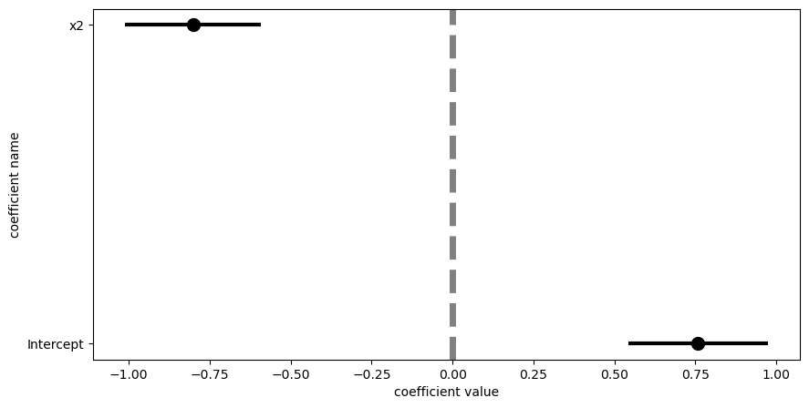

```python
my_coefplot( mod_02 )
```

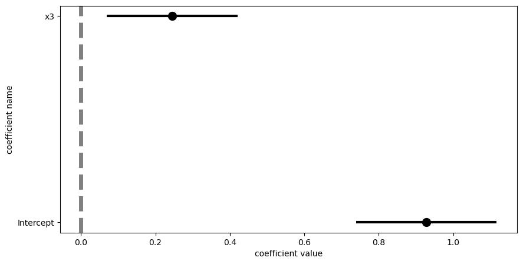

```python
my_coefplot( mod_03 )
```

Which of the 3 models with inputs are the best?

Let's manually calculate the Pseudo Rsquared for `mod_01`. The log-likelihood function is contained within `.llf` attribute.

```python
mod_01.llf
```

```
-109.91997570124617
```

The Pseudo Rsquared requires taking the RATIO of the model's log-likelihood with an INTERCEPT-ONLY model's log-likelihood.

```python
mod_00.llf
```

```
-179.18241339770756
```

```python
mod_01.llf / mod_00.llf
```

```
0.613452925523842
```

```python
1 - mod_01.llf / mod_00.llf
```

```
0.386547074476158
```

This is identical to the Model's Pseudo Rsquared attribute `.prsquared`:

```python
mod_01.prsquared
```

```
0.386547074476158
```

This means, each `smf.poisson()` function call actually fits TWO models...the model you provide with the formula and the intercept only model!!!!

I prefer AIC/BIC to identify the best model when only considering the training set. We know that AIC/BIC automatically penalizes based on the number of features!

```python
[mod.aic for mod in [mod_00, mod_01, mod_02, mod_03]]
```

```
[360.3648267954151, 223.83995140249235, 290.98978610420977, 354.4554689962418]
```

```python
[mod.bic for mod in [mod_00, mod_01, mod_02, mod_03]]
```

```
[362.29665242813945, 227.703602667941, 294.8534373696584, 358.31912026169044]
```

I rarely recommend fitting models one input at a time! The previous exercise was done just for teaching purposes. Instead, start with an intercept-only model, then fit a model with all categorical inputs with additive features, then fit a model with all continuous inputs with linear additive features, then fit a model with ALL inputs with linear additive features.

Since we do not have categorical inputs in this example, we will fit a model with ALL continuous inputs with linear additive features.

```python
mod_04 = smf.poisson( 'y ~ x1 + x2 + x3', data = dfB).fit()
```

```
Optimization terminated successfully.
         Current function value: 1.301963
         Iterations 7
```

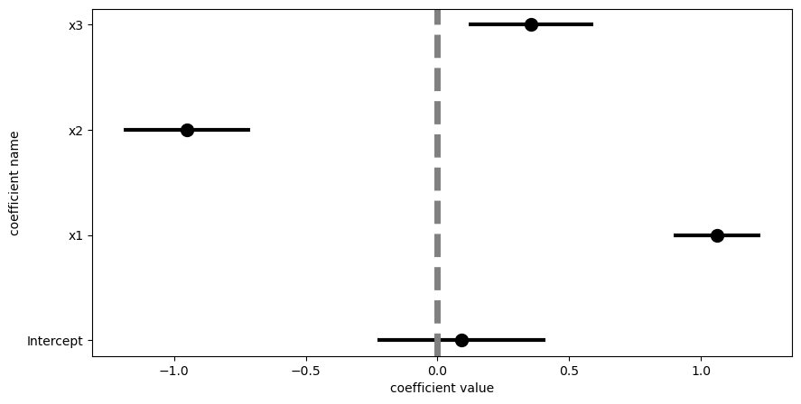

```python
my_coefplot( mod_04 )
```

Never just stop with linear additive features...if you have enough data!!!

We should derive FEATURES from the inputs!

The starting point for more advanced relationships is to use **INTERACTIONS**!!!!!!

Use all MAIN EFFECTS and all PAIR-WISE products (interactions) between the continuous inputs.

```python
mod_05 = smf.poisson( 'y ~ (x1 + x2 + x3) ** 2 ', data = dfB).fit()
```

```
Optimization terminated successfully.
         Current function value: 1.236338
         Iterations 8
```

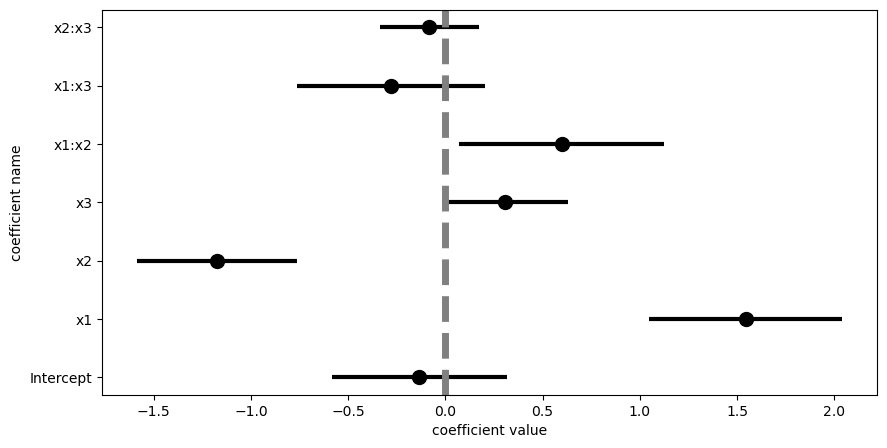

```python
my_coefplot( mod_05 )
```

Use a model with all main effects, pair-wise products, and triplet interactions.

```python
mod_06 = smf.poisson( 'y ~ (x1 + x2 + x3) ** 3', data = dfB).fit()
```

```
Optimization terminated successfully.
         Current function value: 1.235516
         Iterations 8
```

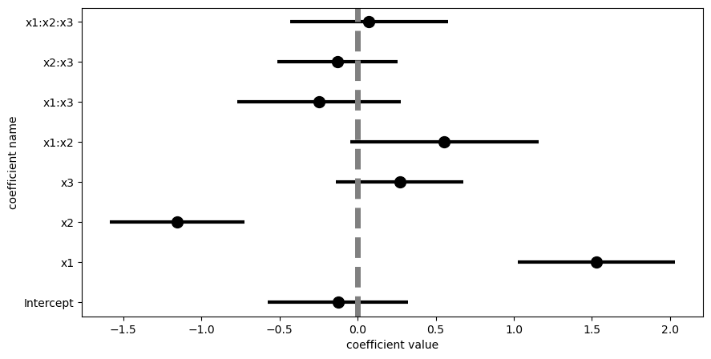

```python
my_coefplot( mod_06 )
```

Include main effects (linear features) with quadratic polynomials but do NOT interact.

```python
mod_07 = smf.poisson( 'y ~ x1 + x2 + x3 + np.power(x1,2) + np.power(x2,2) + np.power(x3,2)', data = dfB).fit()
```

```
Optimization terminated successfully.
         Current function value: 1.275977
         Iterations 11
```

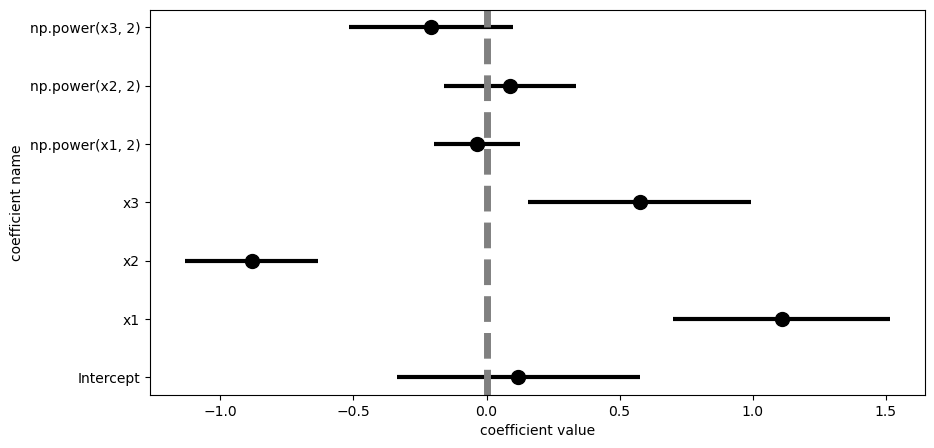

```python
my_coefplot( mod_07 )
```

Next, let's use all main effects, pair wise products, and quadratic polynomials.

```python
mod_08 = smf.poisson( 'y ~ (x1 + x2 + x3) ** 2 + np.power(x1,2) + np.power(x2,2) + np.power(x3,2)', data = dfB).fit()
```

```
Optimization terminated successfully.
         Current function value: 1.213539
         Iterations 12
```

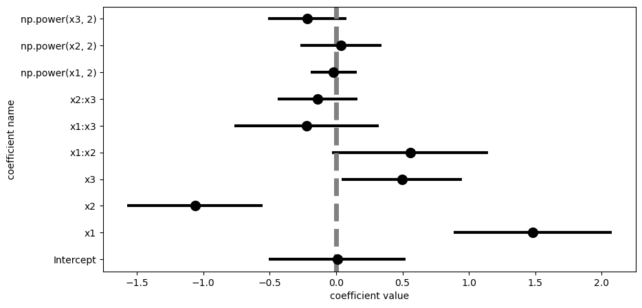

```python
my_coefplot( mod_08 )
```

You do not have to derive the same set of polynomials for all inputs. For example, let's interact `x3` with features derived from the other inputs.

```python
mod_09 = smf.poisson( 'y ~ x3 * ( (x1 + x2)**2 + np.power(x1,2) + np.power(x2,2) )', data = dfB).fit()
```

```
Optimization terminated successfully.
         Current function value: 1.210224
         Iterations 12
```

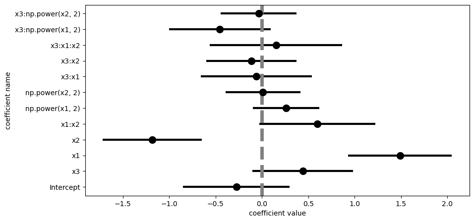

```python
my_coefplot( mod_09 )
```

Or, we can interact `x1` with features derived from the other two.

```python
mod_10 = smf.poisson( 'y ~ x1 * ( (x2 + x3) ** 2 + np.power(x2,2) + np.power(x3,2) )', data = dfB).fit()
```

```
Optimization terminated successfully.
         Current function value: 1.191961
         Iterations 9
```

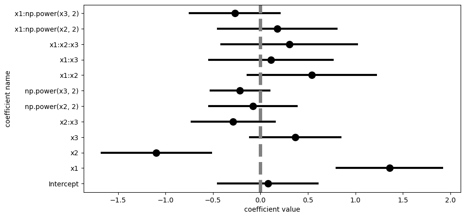

```python
my_coefplot(mod_10)
```

Let's use AIC/BIC to identify the BEST model!!!! Include Pseudo-Rsquared for comparison.

```python
mod_list = [mod_00, mod_01, mod_02, mod_03, mod_04, mod_05, mod_06, mod_07, mod_08, mod_09, mod_10]
```

```python
model_results = pd.DataFrame({'model_name': range(len(mod_list)),
                              'AIC': [mod.aic for mod in mod_list],
                              'BIC': [mod.bic for mod in mod_list],
                              'Pseudo_Rsquared': [mod.prsquared for mod in mod_list]})
```

```python
model_results
```

|  | model_name | AIC | BIC | Pseudo_Rsquared |
| --- | --- | --- | --- | --- |
| 0 | 0 | 360.364827 | 362.296652 | 0.000000 |
| 1 | 1 | 223.839951 | 227.703603 | 0.386547 |
| 2 | 2 | 290.989786 | 294.853437 | 0.199169 |
| 3 | 3 | 354.455469 | 358.319120 | 0.022071 |
| 4 | 4 | 140.800204 | 148.527506 | 0.629427 |
| 5 | 5 | 140.106452 | 153.629232 | 0.648106 |
| 6 | 6 | 142.022618 | 157.477223 | 0.648340 |
| 7 | 7 | 144.149623 | 157.672403 | 0.636824 |
| 8 | 8 | 143.781002 | 163.099258 | 0.654595 |
| 9 | 9 | 147.442811 | 170.624719 | 0.655539 |
| 10 | 10 | 145.580048 | 168.761956 | 0.660737 |

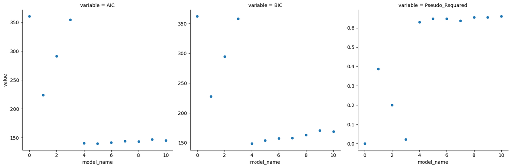

```python
sns.relplot(data = model_results.melt(id_vars=['model_name']),
            x='model_name', y='value',
            col='variable',
            facet_kws={'sharey': False})

plt.show()
```

BIC identifies model 4 as the best, while AIC identifies model 5 as being slightly better than model 4.

```python
mod_04.params
```

```
Intercept    0.090779
x1           1.061161
x2          -0.951502
x3           0.355091
dtype: float64
```

```python
mod_05.params
```

```
Intercept   -0.135447
x1           1.543877
x2          -1.174192
x3           0.306211
x1:x2        0.597478
x1:x3       -0.279640
x2:x3       -0.084197
dtype: float64
```

## Check validity of Poisson regression

The fundamental assumption of the Poisson likelihood is that the **VARIANCE** equals the **MEAN**!!!!

BUT...we must be careful...this idea **does not** apply to the **MARGINAL** distribution of the output!!!

```python
dfB.y.mean()
```

```
2.764705882352941
```

```python
dfB.y.var()
```

```
23.58352941176471
```

But the Variance equaling the mean assumption corresponds to the REGRESSION MODEL!!!!!!!!!!! Or, the variability around the **TREND** increases as the TREND increases. The Variance around the trend is equal to the TREND itself! Thus, the Variance around the trend **DEPENDS** on the inputs!!!!!!

We therefore need to confirm that the Poisson assumption of Variance = Mean is in fact valid!

A simple check is based on the idea that the VARIANCE equals something other than the MEAN:

$$\mathrm{Variance} = \mathrm{Mean} + \alpha \times \mathrm{Mean}^2$$

If the AUXILLARY SLOPE, $\alpha$, is ZERO, then the VARIANCE equals the MEAN and the Poisson regression is valid.

We need the model "fits" of the average count in order to calculate the AUXILLARY test statistic.

Let's do this for the best model according to AIC.

```python
mod_05.fittedvalues[:5]
```

```
0    0.594802
1   -1.439898
2   -1.987421
3   -1.078913
4   -1.943123
dtype: float64
```

We will compare the observed COUNT to the FITTED COUNTS...thus we much undo the LINK or calculate the INVERSE LINK of the `.fittedvalues` attribute.

```python
np.exp( mod_05.fittedvalues )[:5]
```

```
0    1.812672
1    0.236952
2    0.137048
3    0.339965
4    0.143256
dtype: float64
```

Let's create a copy of the training set to separate the validity calculations from the rest of the problem.

```python
df02 = dfB.copy()
```

Include the fitted average counts in the new data set.

```python
df02['avg_count'] = np.exp( mod_05.fittedvalues )
```

```python
df02.head()
```

|  | x1 | x2 | x3 | y | avg_count |
| --- | --- | --- | --- | --- | --- |
| 0 | -0.785973 | -1.327280 | -0.373309 | 2 | 1.812672 |
| 1 | 0.054739 | 0.932546 | -1.527747 | 0 | 0.236952 |
| 2 | -1.172560 | 0.276098 | 0.779124 | 0 | 0.137048 |
| 3 | -0.167313 | 0.853427 | 1.430752 | 0 | 0.339965 |
| 4 | -1.865032 | -0.466554 | 0.004602 | 0 | 0.143256 |

Calculate the new auxillary statistic.

```python
df02['t'] = ( (df02.y - df02.avg_count)**2 - df02.avg_count ) / df02.avg_count
```

The auxillary linear model does **NOT** include an intercept. We are thus only estimating the slope.

```python
aux_mod = smf.ols( 't ~ avg_count - 1', data = df02).fit()
```

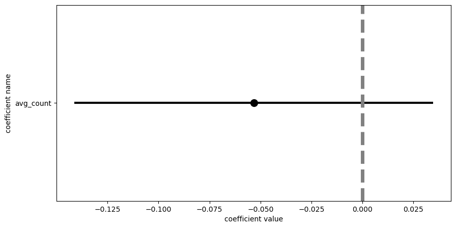

```python
my_coefplot( aux_mod )
```

If the auxillary model's slope was statistically significantly POSITIVE...then the Poisson regression assumption of Variance = MEAN is NOT valid!!!!!!

If Poisson regression is NOT valid, then we need more flexible LIKELIHOODS. The **negative binomial** likelihood is a popular **overdispersed** likelihood for count data.

However, we are **NOT** confident in the SIGN of the auxillary slope! Thus, the Poisson regression assumptions are VALID for **the data and model**!